| title: “Doing Data Science - Assignment2” |
| --- |
| author: “Travis Deason” |
| date: “Sept, 14th 2017” |
| output: pdf_document |

# MSDS 6371 HW 4

#### Question 1. Read Chapter 4 from Statistical Sleuth and answer the conceptual problems at the end of the chapter. Note: You do not need to type these up and turn them in. The answers are at the very end of the chapter

#### Question 2. When wildfires ravage forests, the timber industry argues that logging the burned trees enhances forest recovery; the EPA argues the opposite. The 2002 Biscuit Fire in southwest Oregon provided a test case. Researchers selected 16 fire-affected plots in 2004, before any logging was done, and counted tree seedlings along a randomly located transect pattern in each plot. They returned in 2005, after nine of the plots had been logged, and counted the tree seedlings along the same transects. The percent of seedlings lost from 2004 to 2005 is recorded in the table below for logged (L) and unlogged (U) plots:

*a*. Perform a complete analysis using a rank sum test in SAS. The data is on the LMS in the Data Sets folder: (Logging.csv).

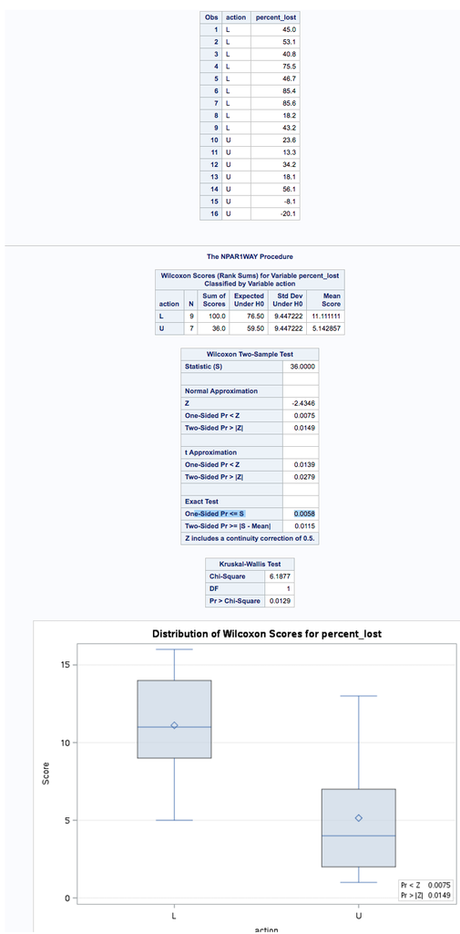

SAS output

*b*. Verify the p-value and confidence interval by running the rank sum test in R (using R function Wilcox.test). (You do not need to repeat the complete analysis … simply cut and paste a screen shot of your code and the output.) You may use: https://www.r-bloggers.com/wilcoxon-mann-whitney-rank-sum-test-or-test-u/ for reference.

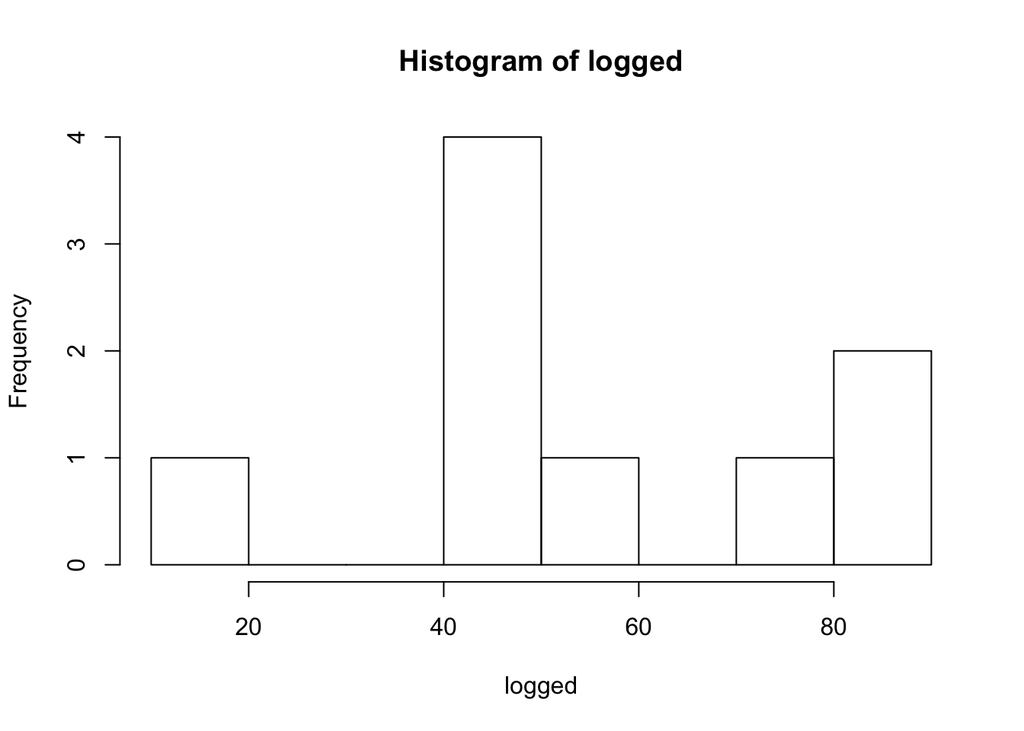

```r
logging = read.csv('data/logging.csv')
names(logging) = c('action', 'percent_lost')
logged = subset(logging, action == 'L')$percent_lost
unlogged = subset(logging, action == 'U')$percent_lost
hist(logged)
```

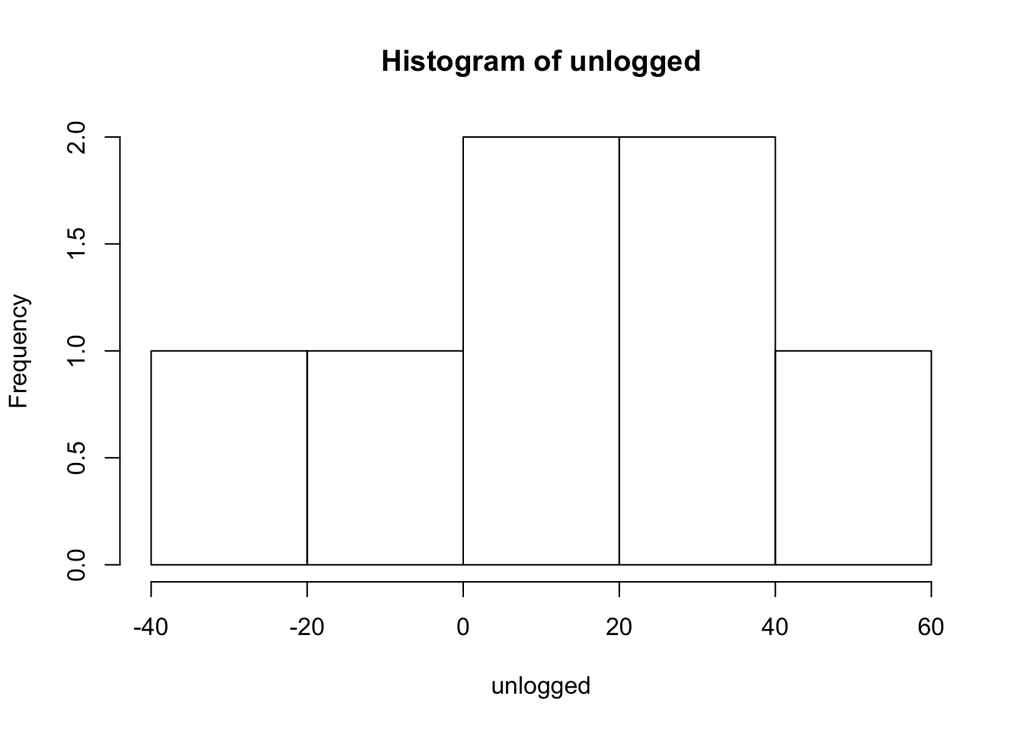

```r
hist(unlogged)
```

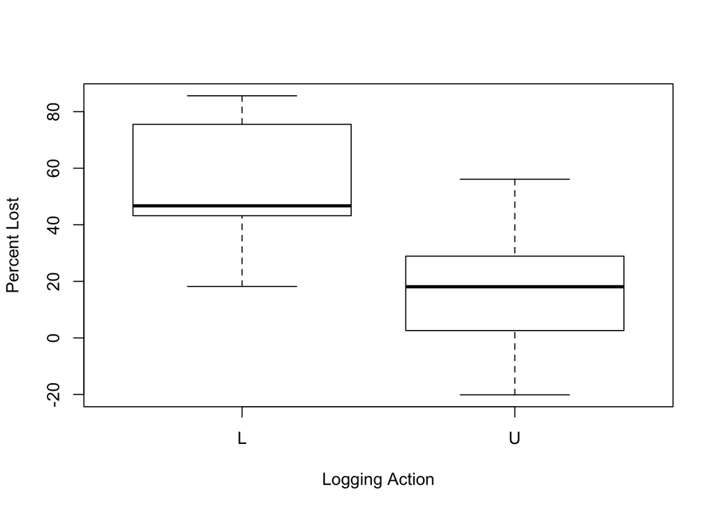

```r
boxplot(logging$percent_lost~action, data=logging, xlab='Logging Action', ylab='Percent Lost')
```

```r
wilcox.test(logged, unlogged, correct=FALSE, exact = TRUE, conf.level= .95)
```

```
##
##  Wilcoxon rank sum test
##
## data:  logged and unlogged
## W = 55, p-value = 0.01154
## alternative hypothesis: true location shift is not equal to 0
```

#### Question 3. Conduct a Welch’s two sample t-test on the Education Data from HW 3 (untransformed). Perform a complete analysis:

*a*. State the problem, address the assumption, be sure and back your answer up with what you know about theory (CLT) as well as with histograms, box plots, q-q plots, etc.

```r
education = read.csv('data/EducationData.csv')
edu_sub = education$Educ == 12
edu12 =  subset(education, Educ == 12)
edu16 = subset(education, Educ == 16)
print ('edu16')
```

```
## [1] "edu16"
```

```r
summary(edu16)
```

```
##     Subject           Educ      Income2005
##  Min.   :    6   Min.   :16   Min.   :   200
##  1st Qu.: 1367   1st Qu.:16   1st Qu.: 32000
##  Median : 2984   Median :16   Median : 56500
##  Mean   : 3411   Mean   :16   Mean   : 69997
##  3rd Qu.: 4528   3rd Qu.:16   3rd Qu.: 89000
##  Max.   :12129   Max.   :16   Max.   :519340
```

```r
print ('edu12')
```

```
## [1] "edu12"
```

```r
summary(edu12)
```

```
##     Subject           Educ      Income2005
##  Min.   :    2   Min.   :12   Min.   :   300
##  1st Qu.: 1636   1st Qu.:12   1st Qu.: 19975
##  Median : 3054   Median :12   Median : 31000
##  Mean   : 3540   Mean   :12   Mean   : 36865
##  3rd Qu.: 4676   3rd Qu.:12   3rd Qu.: 48000
##  Max.   :12139   Max.   :12   Max.   :410008
```

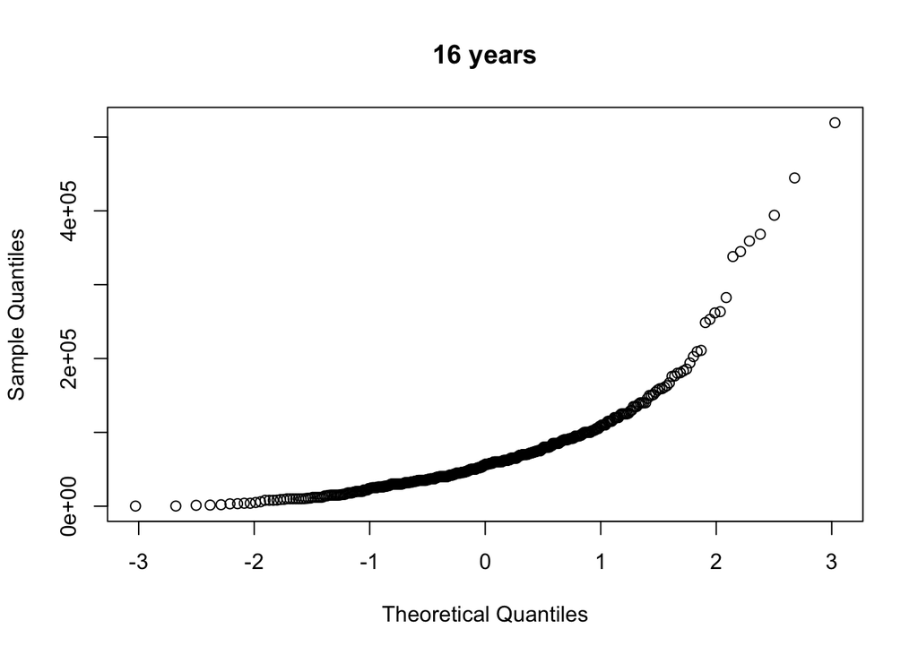

```r
qqnorm(edu16$Income2005, main= '16 years')
```

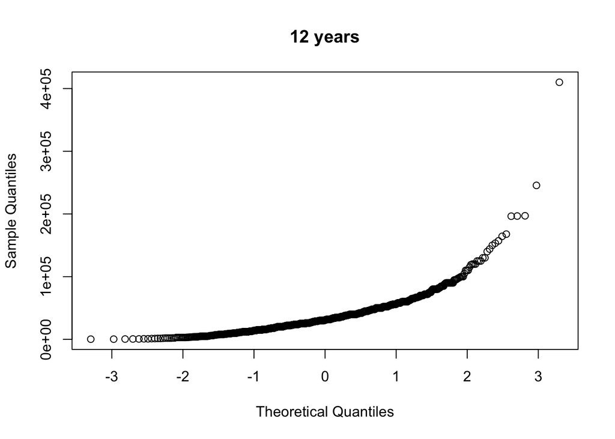

```r
qqnorm(edu12$Income2005, main= '12 years')
```

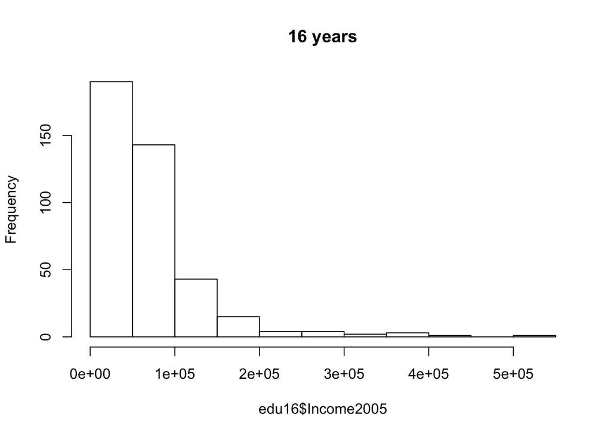

```r
hist(edu16$Income2005, main= '16 years')
```

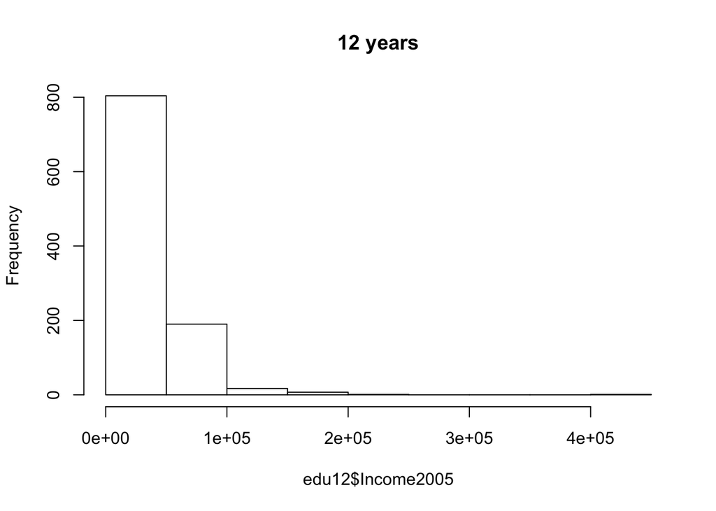

```r
hist(edu12$Income2005, main= '12 years')
```

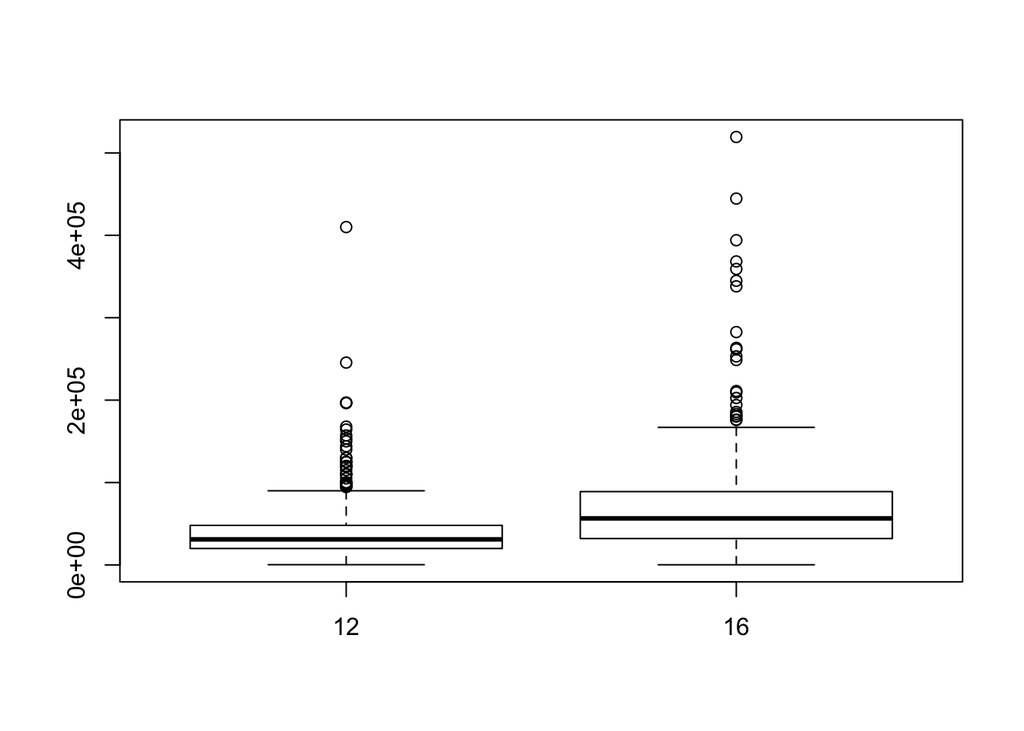

```r
boxplot(Income2005~Educ, data = education)
```

- Based on a study of the incomes of 1426 adults between the ages of 41 and 49 years old with educations between 12 and 16 years. The dataset is non-normal, the data has diffirent varianes, and data is large. We will test the null hypothesis that there is no diffirence between years of education and income levels later in life.

*b*. Show all 6 steps, including a thoughtful, thorough, yet non-technical conclusion. Include a confidence interval.

*c*. Include a scope of inference at the end. (You may copy and paste this from a previous HW if you’d like.)

*d*. Verify the Welch’s t statistic and p-value with R (using R function t.test). Simply cut and paste your R code and output. You may use: http://rcompanion.org/rcompanion/d_02.html for reference. Would you prefer to run the log transformed analysis you ran in HW3 or do you feel this analysis is more appropriate? Why or why not? (Make mention of the assumptions as well as the parameters that each test provides inference on. As you know, they are different

```r
edu12_sample = sample(edu12$Income2005, 406)

t.test(edu16$Income2005,
       edu12_sample,
       var.equal=TRUE,
       alternative = 'two.sided')
```

```
##
##  Two Sample t-test
##
## data:  edu16$Income2005 and edu12_sample
## t = 9.645, df = 810, p-value < 2.2e-16
## alternative hypothesis: true difference in means is not equal to 0
## 95 percent confidence interval:
##  26852.52 40575.05
## sample estimates:
## mean of x mean of y
##  69996.97  36283.19
```

#### Question 4.

*a*. Problem 20 from the text. Show all work. “By hand” here means actually by hand. Simply take a picture of your work and include it in your pdf/doc file. Include your sorted, labeled, and ranked data; your calculation of the mean and standard.

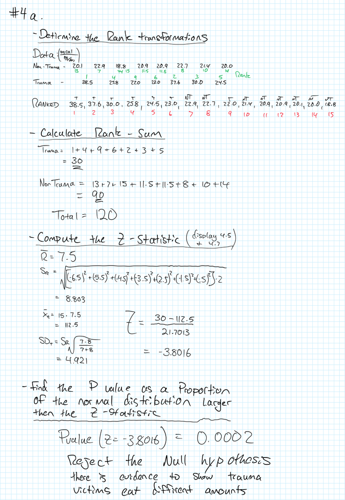

problem 4-1

*b*. Problem 21 from the text. Take a screen capture of the SAS output in addition to your response.

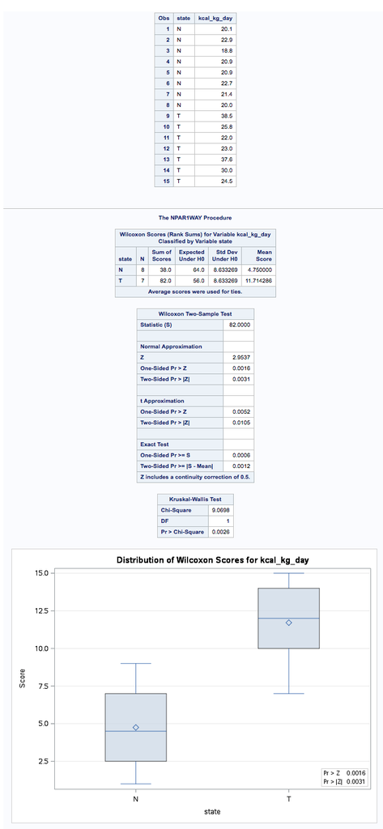

problem 4-2 - SAS output

- The p-value generated from a one sided permutation test in SAS was slightly larger then the value generated from approximating normality in the rank sum value (.0006 verses .0002). This is expected because the sample was not large enough to infer normality. Had the sample been larger, these values would likley be similar as well. It is important to note that both tests will reject the null hypothesis.

*c*. a. Write up a complete analysis using the information you have gained from A and B.

**i**. State the problem.

**ii**. State the assumptions you are making and why you are making them. Justify your decisions. Print out any histograms, q-q plots, box plots, etc. that you use in your justification.

```r
non_trauma = c(20.1, 22.9, 18.8, 20.9, 20.9, 22.7, 21.4, 20.0)
trauma = c(38.5, 25.8, 25.8, 22.0, 23.0, 37.6, 30.0, 24.5)

print('trauma')
```

```
## [1] "trauma"
```

```r
summary(trauma)
```

```
##    Min. 1st Qu.  Median    Mean 3rd Qu.    Max.
##   22.00   24.12   25.80   28.40   31.90   38.50
```

```r
sd(trauma)
```

```
## [1] 6.414938
```

```r
print('non_trauma')
```

```
## [1] "non_trauma"
```

```r
summary(non_trauma)
```

```
##    Min. 1st Qu.  Median    Mean 3rd Qu.    Max.
##   18.80   20.07   20.90   20.96   21.73   22.90
```

```r
sd(non_trauma)
```

```
## [1] 1.379376
```

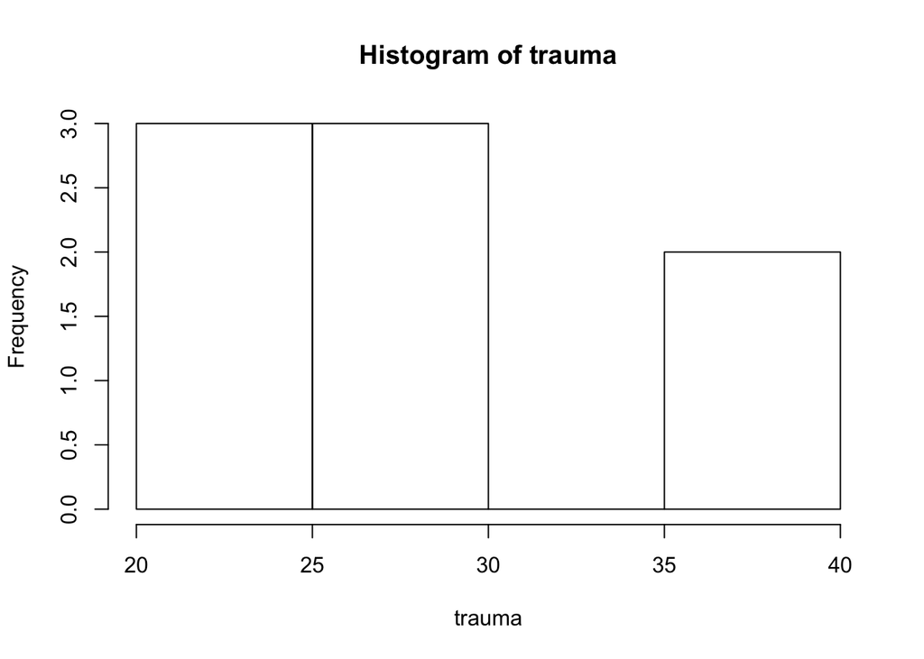

```r
hist(trauma)
```

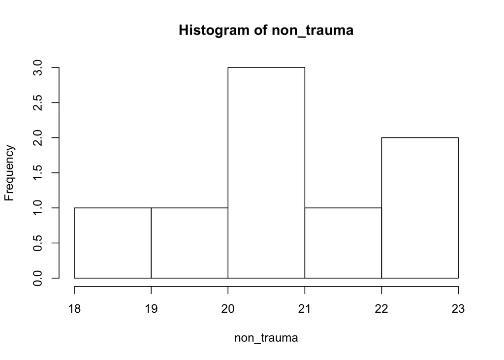

```r
hist(non_trauma)
```

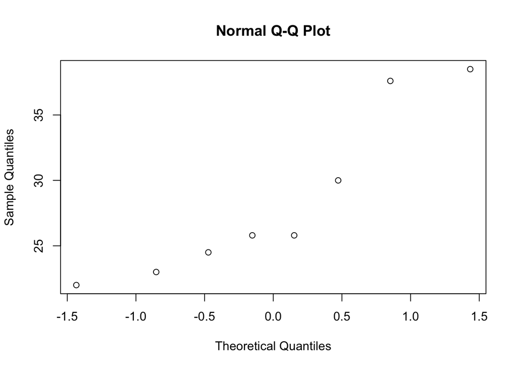

```r
qqnorm(trauma)
```

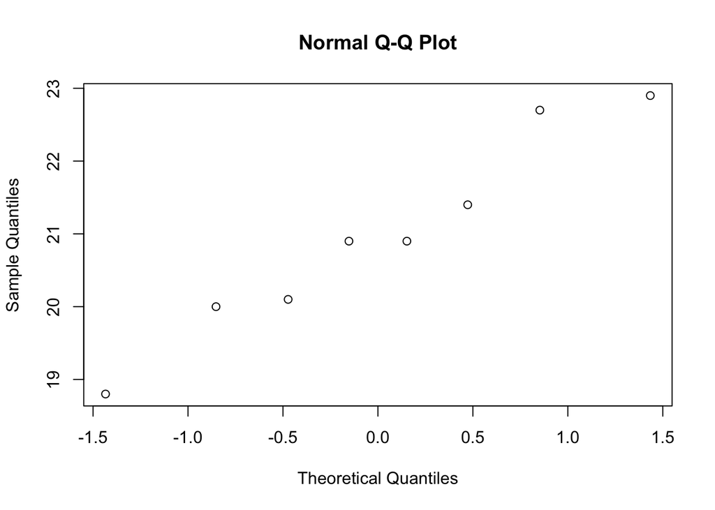

```r
qqnorm(non_trauma)
```

- The assumptions for this expirement is that the samples are indepenent, and randomly selected among their respective groups. The trauma group is not normally distributed, and the variences are very diffirent between the two samples, and the sample size is not large enough to assume the central limit theorm. We are using a rank sum because a t-test will not work. in this case.

**iii**. Show all 6 steps of the hypothesis test for the rank sum test of the Trauma data. Use the critical values, test statistics, p-values, etc. obtained above.

**iv.**. Also include a scope of inference statement.

#### Problem 5. A study was performed to test a new treatment for autism in children. In order to test the new method, parents of children with autism were asked to volunteer for the study in which 9 parents volunteered their children for the study. The children were each asked to complete a 20 piece puzzle. The time it took to complete the task was recorded in seconds. The children then received a treatment (20 minutes of Yoga) and were asked to complete a similar but different puzzle. The data from the study is below:

[figure not shown]

Data From study

*a*. Perform a signed rank test by hand showing the final table with the absolute differences, the signs and the ranks. Also, show your calculation of the z-statistic for each case.

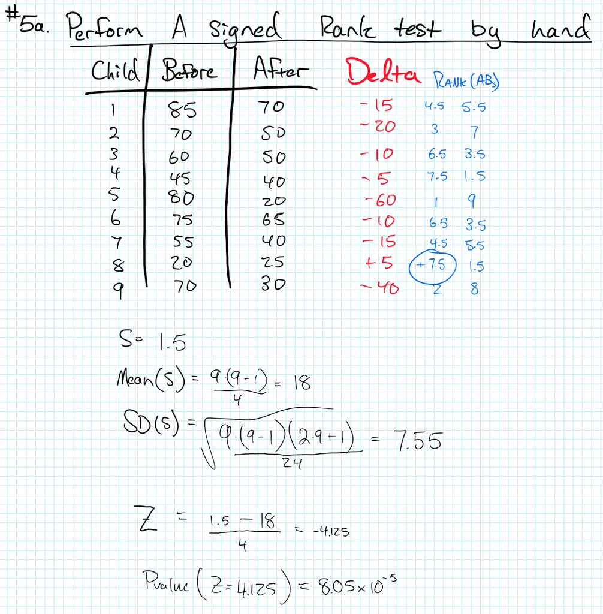

Hand Calc

*b*. Verify your calculation in both SAS and R. Simply cut and paste your code and relevant output.

```r
children <- data.frame(c(1,2,3,4,5,6,7,8,9),
                         c(85,70,60,45,80,75,55,20,70),
                         c(70,50,50,40,20,65,40,25,30))
names(children) <- c('id', 'before', 'after')
children$diff = children$after - children$before
wilcox.test(children$before, children$after,
             paired= TRUE,
             conf.level= .95)
```

```
##
##  Wilcoxon signed rank test with continuity correction
##
## data:  children$before and children$after
## V = 43.5, p-value = 0.01489
## alternative hypothesis: true location shift is not equal to 0
```

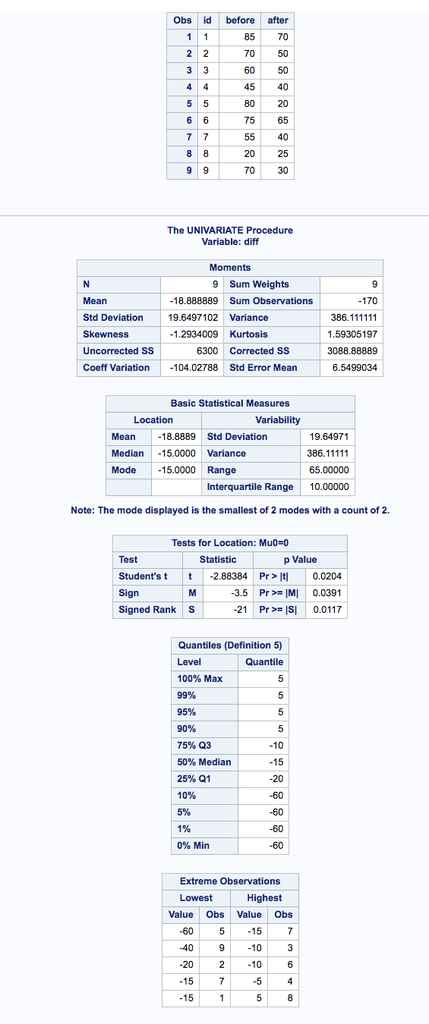

SAS output for Children Study

*c*. Conduct the six step hypothesis test using your calculations from above to test the claim that the yoga treatment was effective in reducing the time to finish the puzzle.

- On the yoga puzzle complietion study, the null hypothesis is that Yoga has no effect on the time taken for children to complete a puzzle. The Test was done in pairs; so each student was given a puzzle prior to performing 20 min of yoga then were asked to complete a similar puzzle after the 20 min of yoga. The assumptions are that the test were similar enough to require similar apptitudte, but not so similar that completing one puzzle would make the subsequent puzzle easier. Since the test are paired, we cannot assume independence, and since the children were voulenteered for the study, we cannot asume this is a representative sample of the population of children.

*d*. Use SAS to conduct the six step hypothesis test using your paired t-test analysis to test the claim that the yoga treatment was effective in reducing the time to finish the puzzle.

*f*. Use your data from above to construct a “complete analysis” of the test that you feel is most appropriate to test the claim that the yoga treatment was effective in reducing the time to finish the puzzle. This is simply formatting your results. You should be able to cut and paste most of the work from above.